# Reproducible Research: Peer Assessment 1

## Loading and preprocessing the data

First, I read in the data, stored in the activity subfolder.

```r
activity <- read.csv("./activity/activity.csv")
```

Next, I look up the properties of the data:

```r
str(activity)
```

```
## 'data.frame':    17568 obs. of  3 variables:
##  $ steps   : int  NA NA NA NA NA NA NA NA NA NA ...
##  $ date    : Factor w/ 61 levels "2012-10-01","2012-10-02",..: 1 1 1 1 1 1 1 1 1 1 ...
##  $ interval: int  0 5 10 15 20 25 30 35 40 45 ...
```

We notice that `activity$date` is not yet in a date format. Let’s convert:

```r
library(lubridate)
activity$date <- as.Date(activity$date, format = "%Y-%m-%d")
```

Now, it should be processable.

## What is mean total number of steps taken per day?

1. Make a histogram of the total number of steps taken each day
2. Calculate and report the mean and median total number of steps taken per day

I use the `dplyr` package (included in `tidyverse`), and execute the following steps: - Filter the NA observations - Then, group by day - Afterwards, take total steps (in dplyr language: sum all steps by `date`) on every day - Write all the previous steps to a data frame

In the last command, I show a histogram of the total number of steps every day.

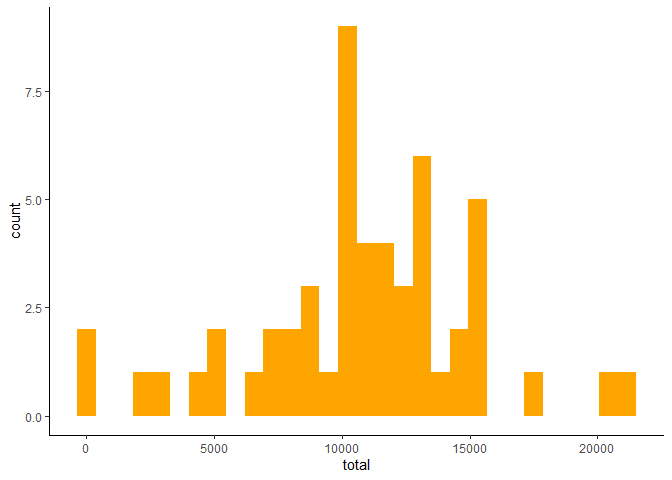

```r
library(tidyverse)

question1 <- activity %>%
        na.omit() %>%
        group_by(date) %>%
        summarise(
            total = sum(steps) )

question1 %>%
        ggplot(aes(x = total)) +
            geom_histogram(fill = "orange") +
            theme_classic()
```

```r
mean(question1$total) ; median(question1$total)
```

```
## [1] 10766.19
```

```
## [1] 10765
```

We can see that mean and median steps per day are about equal, 10766.19. That makes sense because the observations are centured around the mean, judging by the histogram.

## What is the average daily activity pattern?

1. Make a time series plot (i.e. type = “l”) of the 5-minute interval (x-axis) and the average number of steps taken, averaged across all days (y-axis)

I use `dplyr` again to average the steps according to interval, and then construct a plot.

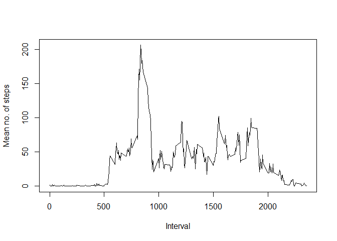

```r
question2 <- activity %>%
        na.omit() %>%
        group_by(interval) %>%
        summarise(
            mean = mean(steps)
    )

plot(question2$interval, question2$mean,
     type = "l", xlab = "Interval", ylab = "Mean no. of steps")
```

2. Which 5-minute interval, on average across all the days in the dataset, contains the maximum number of steps?

```r
question2[which.max(question2$mean),]
```

```
## # A tibble: 1 x 2
##   interval  mean
##      <int> <dbl>
## 1      835  206.
```

Interval 835.

## Imputing missing values

1. Calculate and report the total number of missing values in the dataset (i.e. the total number of rows with NAs)

```r
sum(is.na(activity$steps))
```

```
## [1] 2304
```

2. Devise a strategy for filling in all of the missing values in the dataset. The strategy does not need to be sophisticated. For example, you could use the mean/median for that day, or the mean for that 5-minute interval, etc.
3. Create a new dataset that is equal to the original dataset but with the missing data filled in.

Let’s make it the mean for that 5-minute interval. The data frame `question2` contains the mean values for each interval. Let’s create a new data frame identical to the old one, and then replace the NA entries by the matched entry in the question 2 dataset, and then order to replace them by the means, which are stored in column no. 2!

```r
newactivity <- activity

for (i in 1:nrow(newactivity)) {
                if (is.na(newactivity$steps[i])){
                        newactivity$steps[i] <- question2[match(
                                    newactivity$interval[i],
                                    question2$interval), 2]
        }
}
```

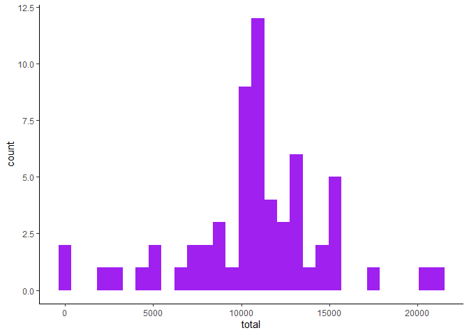

```r
newactivity %>%
    group_by(date) %>%
    summarise(total = sum(as.numeric(steps))) %>%
    ggplot(aes(x = total)) + geom_histogram(fill = "purple") +
    theme_classic()
```

## Are there differences in activity patterns between weekdays and weekends?

1. Create a new factor variable in the dataset with two levels – “weekday” and “weekend” indicating whether a given date is a weekday or weekend day.

I create a vector indicating weekend days. Due to not having English locale on this PC, I use another language (Dutch). Then, I create a factor in the original activity dataset indicating whether the day is a weekday or not by the `ifelse` function.

```r
weekend <- c("zaterdag","zondag")

activity <- activity %>%
    mutate(day = factor(
        ifelse(weekdays(activity$date) %in% weekend,
               "weekend",
               "weekday") )
        )
```

2. Make a panel plot containing a time series plot (i.e. type=“l”) of the 5-minute interval (x-axis) and the average number of steps taken, averaged across all weekday days or weekend days (y-axis). See the README file in the GitHub repository to see an example of what this plot should look like using simulated data.

I omit the NA’s, transform the dataframe again, so that I can take the mean per interval per category (weekday or weekend), and then plot the interval (x) against that mean (y), and differentiate between the category of day.

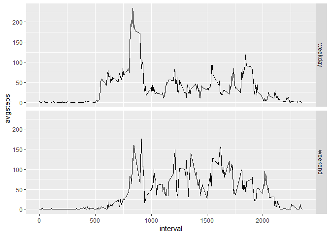

```r
activity %>%
    na.omit() %>%
    group_by(interval, day) %>%
    summarise(avgsteps = mean(steps)) %>%
        ggplot(aes(interval, avgsteps)) +
            geom_line() +
            facet_grid(vars(day))
```